# XDAS2020 HW7: Parametric and non-parametric tests for one-sample, paired, and two-sample tests

# Permutation (“shuffle”) test

Instead of trying to compute statistics using a parametric model of the data, we could just rearrange the group labels and compute the number of times we see a difference in means at least as great as the one we have observed.

## Q5: Permutation test with mouse data

# What if the data are not normally distributed?

Sometimes our data don’t look that normal, so it’s not clear whether a t-test is appropriate to compare them. Here we will investigate a dataset on plasma triglyceride levels before and after diet and exercise changes:

```r
###############################################################################
# plasma triglyceride levels in the population (mg/ml)
# borderline high = 2-4 vs. normal < 2
# testing before and after diet and exercise changes (expect a decrease)
pre = c(2.55,3.38,2.37,4.11,3.27,2.58,4.20,3.22,5.10,2.62,3.06,1.23,2.27,2.24,
        1.39,2.63,2.61,4.30,1.46,3.35,2.79,2.42,4.63,1.57)
post = c(1.59,3.51,1.44,2.32,1.75,1.67,1.90,1.37,2.72,1.80,2.40,2.01,2.41,1.38,
         1.18,4.31,2.09,2.32,2.63,2.25,1.71,2.01,1.95,3.46)
###############################################################################
```

## Exploratory data analysis

It’s always a good idea to plot data to take an initial feel for it. Histograms and normal-QQ plots can both be very helpful for this purpose. We can also use the *Shapiro-Wilk* test to see whether the data follow a normal distribution.

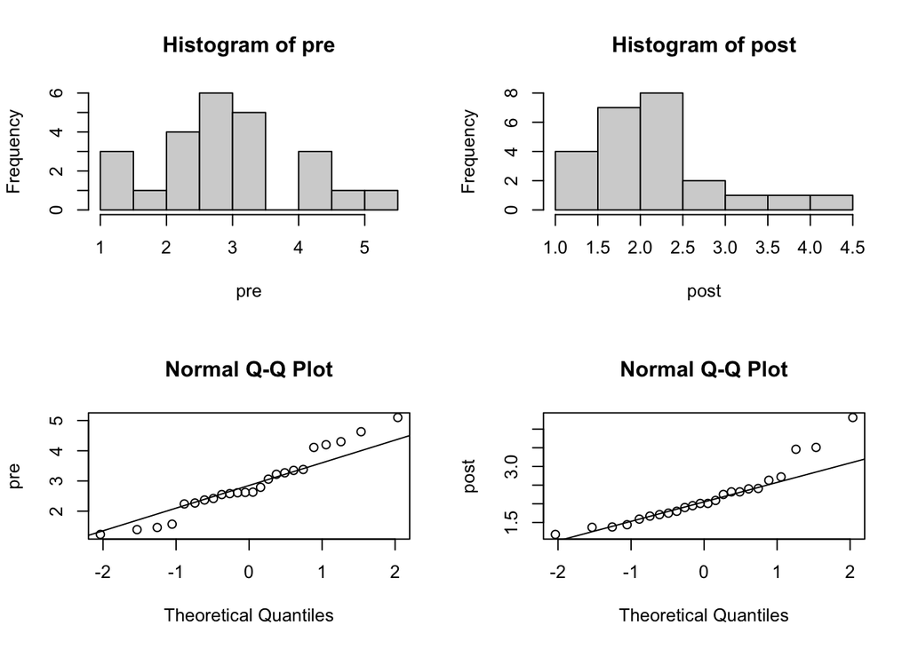

```r
################################################################
## histograms (breaks = 10)
par(mfrow=c(2,2))

# raw data
hist(pre,breaks=10)
hist(post,breaks=10)

################################################################
## QQ-plots: use `qqnorm(data, ylab="data"; qqline(data)`

# QQ-plot - raw data for pre and post
qqnorm(pre,ylab="pre"); qqline(pre)
qqnorm(post,ylab="post"); qqline(post)
```

```r
################################################################
## Shapiro-Wilk tests - `shapiro.test(your_data_here)`
shapiro.test(pre)   # pre-treatment
```

```
##
##  Shapiro-Wilk normality test
##
## data:  pre
## W = 0.95695, p-value = 0.3802
```

```r
shapiro.test(post)  # post-treatment
```

```
##
##  Shapiro-Wilk normality test
##
## data:  post
## W = 0.89421, p-value = 0.01626
```

$\Rightarrow$ *What do you think about whether these data look close enough to normal to perform a t-test?*

## Q6: Transformation

When the data do not look to be sufficiently normal, we can try performing tests on data that have been **transformed** using functions such as the `log()`, `sqrt()`, or `arcsin()`. This can make data look more normal, so that parametric tests may be performed on them.

### Log transform

Many types of data follow a log-normal distribution, such as exponential growth (cell count doubles with each division), systolic blood presssure, and the latency period for infectious diseases. Taking the log of distributions with a long right-skewed tail stretches out the small values and compresses the larger ones, which can render the data more normal-looking. Let’s see if this helps our dataset.

*Note:* By default, the `log()` function uses the **natural log**. You can specify other bases with the `base` parameter; convenience functions such as `log10()` and `log2()` are also available.

- Do the same checks as above, except use the log of the distributions instead.

```r
# check distributions after log-transformation
par(mfrow=c(2,2))

# histograms



# QQ plots



## Shapiro-Wilk tests
```

[output not shown]

$\Rightarrow$ *Did the log transform make the data more normal?*

### Perform paired $t$-tests on the original and log-transformed data

```r
# paired t-tests using raw and transformed data
```

[output not shown]

$\Rightarrow$ *How do these $t$-test compare? Which $t$-test is more appropriate, and why?*